# Prevalence of Rare Disease Codes in the Duke Medical System

Gary Koplik

During our meeting with Kin-Wah and Olivier, Kin-Wah said he was most curious about the utility of the mappings between rare diseases and other coding systems. This document does a first pass exploration of this simply by looking at the most prevalent rare disease codes in the Duke Medical System.

## Methodology

We finally subsetted the patients who have exhibited a rare disease (as defined by containing an ICD-9 or ICD-10 code in the NLM files mapping rare diseases to ICD) using the new, corrected files sent by Kin-Wah.

Here, I started with the subset of patients that at one point were assigned an ICD-9 or ICD-10 code of a rare disease (from the mappings).

I then filtered these data to only keep the rows containing a rare disease ICD code (remember, we have restructured the data such that there is only one ICD-9 or ICD-10 code per row).

I finally further filtered these data such that the combination of patient ID and ICD code was unique / a primary key in this final data frame (for example, if a patient has cystic fibrosis with the specified ICD code in a visit in October of 2012 and shows the same code in October of 2013, then one of these rows will be deleted). I did this to avoid double counting patients with respect to determining prevalence of rare diseases in this data set. *Note, we can go back later to look **only** at patients who are assigned a rare disease code more than once, which is likely a more robust indication of whether a patient has a rare disease vs possibly having a rare disease*.

### Graphs with All Rare Disease Codes

These figures show the top 20 ICD-9 codes and ICD-10 codes by frequency. Here, I used all ICD codes contained in the files from the National Library of Medicine. Rather than show the ICD codes on the y-axis, I have replaced those values with the equivalent descriptions from the files from the NLM (the 5th column in those text files).

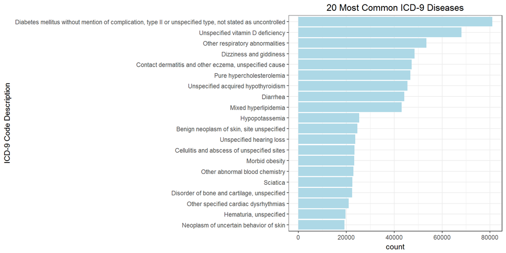

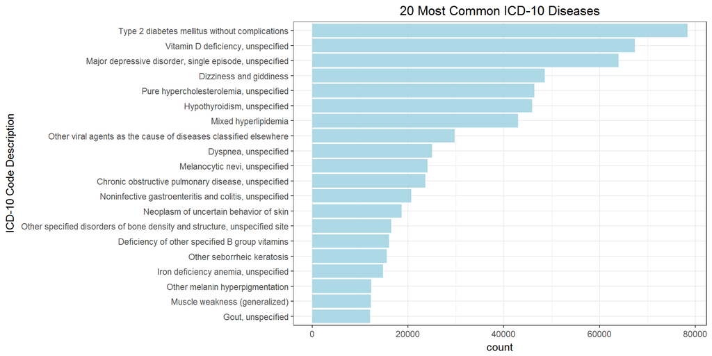

Given the names that are showing up here, in particular Type II Diabetes, clearly there are issues we should further explore. Since the mappings between these ICD codes are not necessarily 1 ICD code to 1 disease (some are 1 ICD code to many diseases), I will not discuss which diseases are mapping to these codes with these graphs.

In the next section, however, I address this discrepancy between ICD code and rare disease name by including tables of the ICD code and the unique rare disease to which it maps. Since the Diabetes issue resurfaces there, this specific example will be further discussed momentarily.

### Graphs with Only 1 Rare Disease per Code

Here, I specifically looked at only ICD codes that uniquely mapped to exactly one “rare” disease in our mapping files.

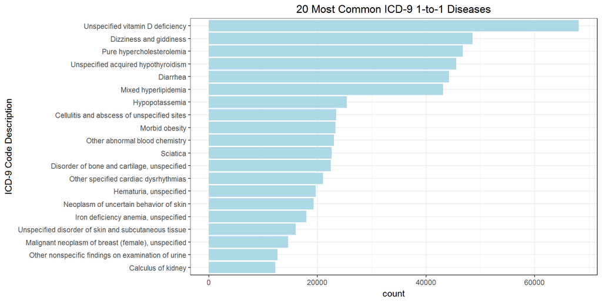

| ICD-9 Code | Rare Disease Name | Code Description |
| --- | --- | --- |
| 268.9 | Rickets | Unspecified vitamin D deficiency |
| 780.4 | Dysequilibrium syndrome | Dizziness and giddiness |
| 272.0 | Hyperlipoproteinemia type 2 | Pure hypercholesterolemia |
| 244.9 | Thyrotropin deficiency, isolated | Unspecified acquired hypothyroidism |
| 787.91 | Immunodysregulation, polyendocrinopathy and enteropathy X-linked | Diarrhea |
| 272.2 | Hyperlipidemia type 3 | Mixed hyperlipidemia |
| 276.8 | Gitelman syndrome | Hypopotassemia |
| 682.9 | Wells syndrome | Cellulitis and abscess of unspecified sites |
| 278.01 | Proopiomelanocortin deficiency | Morbid obesity |
| 790.6 | Renal hypouricemia | Other abnormal blood chemistry |
| 724.3 | Piriformis syndrome | Sciatica |
| 733.90 | Spondyloenchondrodysplasia | Disorder of bone and cartilage, unspecified |
| 427.89 | His bundle tachycardia | Other specified cardiac dysrhythmias |
| 599.70 | Loin pain hematuria syndrome | Hematuria, unspecified |
| 238.2 | Muir-Torre syndrome | Neoplasm of uncertain behavior of skin |
| 280.9 | Iron-refractory iron deficiency anemia | Iron deficiency anemia, unspecified |
| 709.9 | Tight skin contracture syndrome, lethal | Unspecified disorder of skin and subcutaneous tissue |
| 174.9 | Inflammatory breast cancer | Malignant neoplasm of breast (female), unspecified |
| 791.9 | 3-Hydroxyisobutyric aciduria | Other nonspecific findings on examination of urine |
| 592.0 | Dent disease | Calculus of kidney |

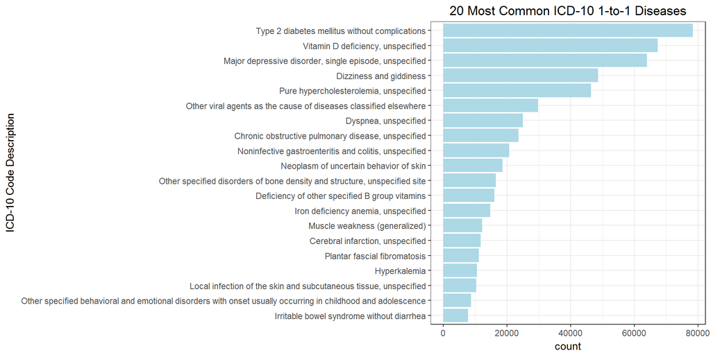

| ICD-10 Code | Rare Disease Name | Code Description |
| --- | --- | --- |
| E11.9 | Maturity-onset diabetes of the young, type 2 | Type 2 diabetes mellitus without complications |
| E55.9 | Rickets | Vitamin D deficiency, unspecified |
| F32.9 | Mal de debarquement | Major depressive disorder, single episode, unspecified |
| R42 | Dysequilibrium syndrome | Dizziness and giddiness |
| E78.00 | Hyperlipoproteinemia type 2 | Pure hypercholesterolemia, unspecified |
| B97.89 | Togaviridae disease | Other viral agents as the cause of diseases classified elsewhere |
| R06.00 | Paraneoplastic Neurologic Disorders | Dyspnea, unspecified |
| J44.9 | Bronchiolitis obliterans | Chronic obstructive pulmonary disease, unspecified |
| K52.9 | WDHA syndrome | Noninfective gastroenteritis and colitis, unspecified |
| D48.5 | Dermatofibrosarcoma protuberans | Neoplasm of uncertain behavior of skin |
| M85.80 | Melorheostosis | Other specified disorders of bone density and structure, unspecified site |
| E53.8 | Biotinidase deficiency | Deficiency of other specified B group vitamins |
| D50.9 | Iron-refractory iron deficiency anemia | Iron deficiency anemia, unspecified |
| M62.81 | Neuropathy ataxia retinitis pigmentosa syndrome | Muscle weakness (generalized) |
| I63.9 | Neonatal stroke | Cerebral infarction, unspecified |
| M72.2 | Ledderhose disease | Plantar fascial fibromatosis |
| E87.5 | Gordon syndrome | Hyperkalemia |
| L08.9 | Erosive pustular dermatosis of the scalp | Local infection of the skin and subcutaneous tissue, unspecified |
| F98.8 | Psychosocial short stature | Other specified behavioral and emotional disorders with onset usually occurring in childhood and adolescence |
| K58.9 | Ichthyosis bullosa of Siemens | Irritable bowel syndrome without diarrhea |

### Back to the Diabetes Example

The issue of rare vs. not rare for all of these cases goes well beyond my domain knowledge, so I will leave further checking to you, but I do know that Type II Diabetes isn’t exactly rare.

Since the distinguishing factor for the rareness of diabetes is age, here I include a kernel density plot of age of patients with the ICD-10 code for Type II Diabetes (E11.9) in our rare patients data set (78,370 patients in this subset). According to [this NCBI article](https://www.ncbi.nlm.nih.gov/pmc/articles/PMC3363133), 63% of cases present by age 25, 79% by age 35, and 96% by age 55. Although this density plot is by no means causal proof, it appears highly unlikely that this age distribution would represent such a cohort independent of other Diabetes cases:

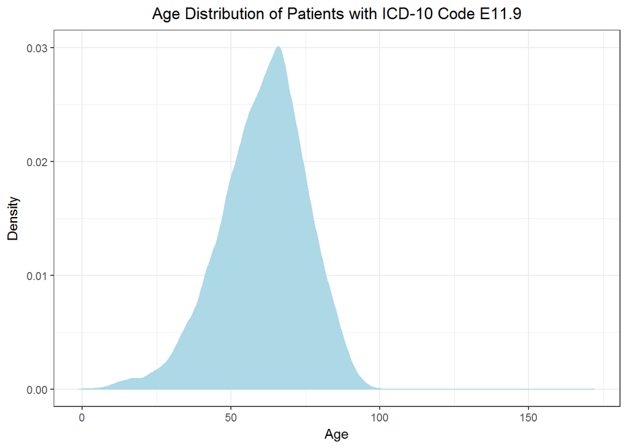

### The Takeaway

As we can see from these tables, we have a recurring issue of rare diseases being grouped together with more common diseases under both ICD-9 and ICD-10, and looking at diseases that have unique mappings with respect to our rare disease data set clearly is not sufficient to guarantee that we only look at patients with true rare diseases.

Most notably, we need to address the question:

*How useful are our mappings with respect to quantifying the burden of rare disease on the Duke Medical System, and how can we best subset the mapping relationships we have such that we can be sure to look at a **true** subset of rare disease patients in the Duke Medical Sytem?*

It’s unclear at this point whether / how much of this issue is the result of mapping diseases to ICD codes by “walking up” the hierarchy and how much is the result of the “for billing” nature to the ICD hierarchy. For example, the Type II Diabetes issue presented here is an example of the latter problem, with the ICD-10 code E11.9 incorporating other forms of Diabetes into it.

Regardless of the cause of the problem, I believe this is the most important issue standing between us and our goal of quantifying the burden of rare disease. $\hspace{4ex} _\blacksquare$